# Study on the Link Between Academic Path and Career Satisfaction

Ramy Lazghab

2024-12-27

# 1 Introduction

This study examines how well individuals’ current professional roles align with their academic backgrounds and skills, and how this alignment impacts career satisfaction. To explore this, we employ Principal Component Analysis (PCA) and Multiple Correspondence Analysis (MCA) as key analytical methods. These techniques help uncover patterns in the data and provide insights into the relationships between variables.

# 2 Data Loading

First, we start by loading our dataset and taking a closer look at its structure and contents. This step ensures we understand what the data looks like and helps us identify any duplicates or inconsistencies.

```r
# Load the dataset
data <- read.csv("Data.csv", header = TRUE, sep = ",", fileEncoding = "ISO-8859-1")

# Inspect the structure and content of the dataset
str(data)          # View structure of the dataset
```

```
## 'data.frame':    41 obs. of  45 variables:
##  $ Timestamp                                                                                                                                         : chr  "2024/11/23 9:25:48 PM GMT+1" "2024/11/24 8:05:47 AM GMT+1" "2024/11/24 8:20:39 AM GMT+1" "2024/11/24 9:29:30 AM GMT+1" ...
##  $ Quel.est.votre.age..                                                                                                                              : chr  "55+" "35-44" "45-54" "55+" ...
##  $ Quel.est.votre.niveau.d.etudes..                                                                                                                  : chr  "Baccalaureat" "Licence" "Autre" "Master" ...
##  $ Quel.est.votre.domaine.de.travail.principal..                                                                                                     : chr  "Commerce" "Informatique / IT" "Autre" "Commerce" ...
##  $ Combien.d.annees.d.experience.professionnelle.avez.vous..                                                                                         : chr  "10+ ans" "3-5 ans" "10+ ans" "10+ ans" ...
##  $ Pertinence.des.Competences.et.de.la.Formation....Mon.poste.actuel.correspond.a.mes.competences.et.a.ma.formation..                                : chr  "pdtd" "tafd" "Neutre" "tafd" ...
##  $ Pertinence.des.Competences.et.de.la.Formation....Les.competences.developpees.pendant.mes.etudes.sont.pertinentes.pour.mon.travail.actuel..        : chr  "pdtd" "pdtd" "Neutre" "pdtd" ...
##  $ Pertinence.des.Competences.et.de.la.Formation....Mon.role.actuel.est.aligne.avec.mon.domaine.de.specialisation..                                  : chr  "pdtd" "Neutre" "pdtd" "pdtd" ...
##  $ Pertinence.des.Competences.et.de.la.Formation....Mon.niveau.de.qualification.est.suffisant.pour.bien.accomplir.mes.taches..                       : chr  "tafd" "tafd" "tafd" "tafd" ...
##  $ Pertinence.des.Competences.et.de.la.Formation....Mes.compétences.techniques.sont.nécessaires.pour.réussir.dans.mon.poste..                        : chr  "tafd" "tafd" "Neutre" "tafd" ...
##  $ Pertinence.des.Competences.et.de.la.Formation....Mon.role.necessite.une.expertise.specifique.que.j.ai.acquise.auparavant..                        : chr  "Neutre" "tafd" "tafd" "tafd" ...
##  $ Pertinence.des.Competences.et.de.la.Formation....Je.sens.que.mon.poste.est.une.progression.naturelle.apres.mes.etudes.formations..                : chr  "Neutre" "tafd" "pdtd" "tafd" ...
##  $ Pertinence.des.Competences.et.de.la.Formation....Mon.travail.correspond.aux.attentes.professionnelles.que.j.avais.apres.mes.etudes..              : chr  "Neutre" "Neutre" "Neutre" "pdtd" ...
##  $ Pertinence.des.Competences.et.de.la.Formation....Le.contenu.de.ma.formation.correspond.aux.exigences.actuelles.de.mon.metier..                    : chr  "tafd" "tafd" "pdtd" "pdtd" ...
```

[output cut: 31 more lines]

```r
summary(data)      # Get summary statistics
```

```
##   Timestamp         Quel.est.votre.age.. Quel.est.votre.niveau.d.etudes..
##  Length:41          Length:41            Length:41
##  Class :character   Class :character     Class :character
##  Mode  :character   Mode  :character     Mode  :character
##  Quel.est.votre.domaine.de.travail.principal..
##  Length:41
##  Class :character
##  Mode  :character
##  Combien.d.annees.d.experience.professionnelle.avez.vous..
##  Length:41
##  Class :character
##  Mode  :character
##  Pertinence.des.Competences.et.de.la.Formation....Mon.poste.actuel.correspond.a.mes.competences.et.a.ma.formation..
##  Length:41
##  Class :character
##  Mode  :character
##  Pertinence.des.Competences.et.de.la.Formation....Les.competences.developpees.pendant.mes.etudes.sont.pertinentes.pour.mon.travail.actuel..
##  Length:41
##  Class :character
##  Mode  :character
##  Pertinence.des.Competences.et.de.la.Formation....Mon.role.actuel.est.aligne.avec.mon.domaine.de.specialisation..
##  Length:41
##  Class :character
##  Mode  :character
##  Pertinence.des.Competences.et.de.la.Formation....Mon.niveau.de.qualification.est.suffisant.pour.bien.accomplir.mes.taches..
##  Length:41
##  Class :character
##  Mode  :character
##  Pertinence.des.Competences.et.de.la.Formation....Mes.compétences.techniques.sont.nécessaires.pour.réussir.dans.mon.poste..
##  Length:41
##  Class :character
##  Mode  :character
##  Pertinence.des.Competences.et.de.la.Formation....Mon.role.necessite.une.expertise.specifique.que.j.ai.acquise.auparavant..
##  Length:41
##  Class :character
##  Mode  :character
##  Pertinence.des.Competences.et.de.la.Formation....Je.sens.que.mon.poste.est.une.progression.naturelle.apres.mes.etudes.formations..
##  Length:41
##  Class :character
##  Mode  :character
```

[output cut: 117 more lines]

```
##  Length:41
##  Class :character
##  Mode  :character
##  Objectifs.et.Attentes.pour.l.Avenir....Mon.objectif.est.d.avoir.un.role.avec.un.niveau.eleve.d.autonomie..
##  Length:41
##  Class :character
##  Mode  :character
##  Objectifs.et.Attentes.pour.l.Avenir....La.stabilite.professionnelle.est.un.critere.essentiel.pour.mon.futur.metier..
##  Length:41
##  Class :character
##  Mode  :character
##  Objectifs.et.Attentes.pour.l.Avenir....Je.cherche.un.emploi.qui.me.permette.de.voyager.ou.de.travailler.a.l.international..
##  Length:41
##  Class :character
##  Mode  :character
```

```r
head(data)         # Display the first few rows
```

```
##                      Timestamp Quel.est.votre.age..
## 1  2024/11/23 9:25:48 PM GMT+1                  55+
## 2  2024/11/24 8:05:47 AM GMT+1                35-44
## 3  2024/11/24 8:20:39 AM GMT+1                45-54
## 4  2024/11/24 9:29:30 AM GMT+1                  55+
## 5  2024/11/24 9:35:44 AM GMT+1                35-44
## 6 2024/11/24 10:26:18 AM GMT+1                45-54
##   Quel.est.votre.niveau.d.etudes..
## 1                     Baccalaureat
## 2                          Licence
## 3                            Autre
## 4                           Master
## 5                          Licence
## 6                         Doctorat
##   Quel.est.votre.domaine.de.travail.principal..
```

[output cut: 293 more lines]

```r
# Remove duplicates if any
data <- distinct(data)
```

# 3 Data Preprocessing

To make the data ready for analysis, we preprocess it by recoding responses, handling missing values, and standardizing the data. This ensures that our analyses are accurate and meaningful.

## 3.1 Bloc 1: Pertinence (Relevance)(PCA)

Here, we focus on understanding how respondents perceive the relevance of their skills and education in their current roles. Using PCA, we explore patterns and visualize the relationships between variables.

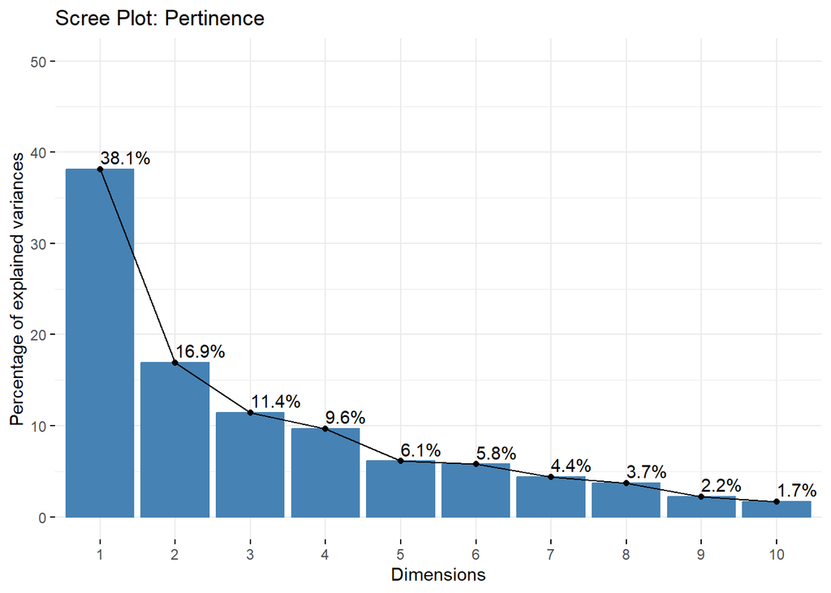

```r
# Select Pertinence-related columns
pertinence_columns <- grep("Pertinence", names(data), value = TRUE)
pertinence_data <- data %>%
  select(all_of(pertinence_columns)) %>%
  # Recode Likert responses into numeric values: pdtd -> 1, Neutre -> 2, tafd -> 3
  mutate(across(everything(),
                ~ recode(.,
                         "pdtd" = 1,
                         "Neutre" = 2,
                         "tafd" = 3,
                         .default = NA_real_)))

# Impute missing values with column means
pertinence_data[is.na(pertinence_data)] <- apply(pertinence_data, 2, function(x) mean(x, na.rm = TRUE))

# Standardize the data to have zero mean and unit variance
pertinence_scaled <- scale(pertinence_data)

# Identify and remove constant/zero-variance columns
col_variances <- apply(pertinence_scaled, 2, var)  # Calculate variances for each column
pertinence_scaled <- pertinence_scaled[, col_variances > 0]  # Remove columns with zero variance

# Perform PCA
pertinence_pca <- prcomp(pertinence_scaled, center = TRUE, scale. = TRUE)

# Scree plot to visualize the proportion of variance explained
fviz_screeplot(pertinence_pca, addlabels = TRUE, ylim = c(0, 50)) +
  ggtitle("Scree Plot: Pertinence")
```

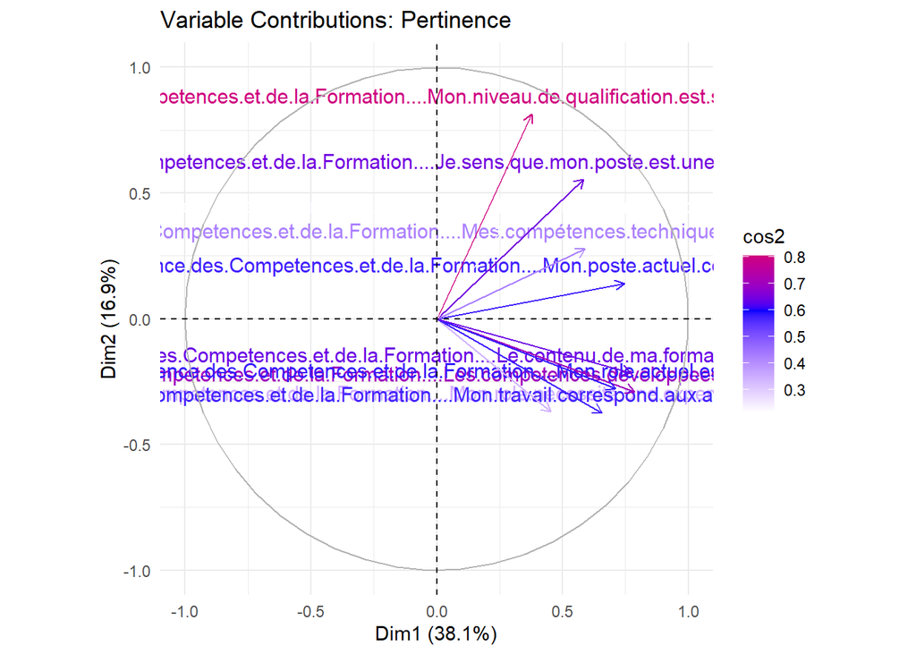

```r
# Variable biplot: Visualize how variables contribute to the principal components
fviz_pca_var(pertinence_pca, col.var = "cos2") +
  scale_color_gradient2(low = "white", mid = "blue", high = "red", midpoint = 0.6) +
  theme_minimal() +
  ggtitle("Variable Contributions: Pertinence")
```

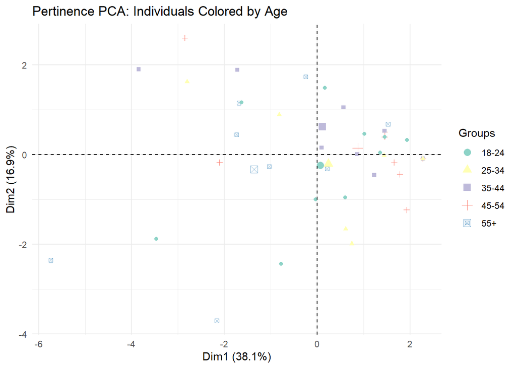

```r
# Ensure age is treated as a factor (categorical variable)
data$age_factor <- factor(data$Quel.est.votre.age..,
                          levels = c("18-24", "25-34", "35-44", "45-54", "55+", "Autre"))

# Filter the 'age' column to include only complete cases in pertinence_data
age_filtered <- data$age_factor[complete.cases(pertinence_data)]

# Ensure the length of age_filtered matches the number of individuals in pertinence_scaled
age_filtered <- age_filtered[1:nrow(pertinence_scaled)]

# Create the PCA plot colored by age with a discrete color palette
fviz_pca_ind(pertinence_pca, geom = "point", habillage = age_filtered) +
  scale_color_brewer(palette = "Set3") +
  ggtitle("Pertinence PCA: Individuals Colored by Age") +
  theme_minimal()
```

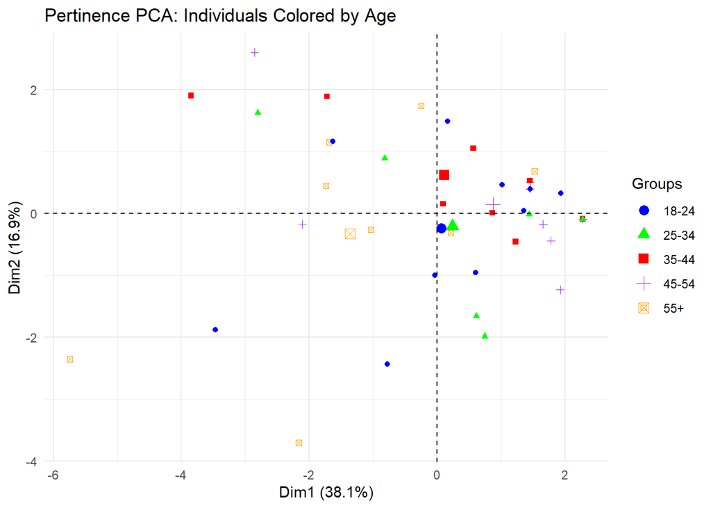

```r
# Create the PCA plot colored by age with custom colors
fviz_pca_ind(pertinence_pca, geom = "point", habillage = age_filtered) +
  scale_color_manual(values = c("18-24" = "blue", "25-34" = "green", "35-44" = "red",
                               "45-54" = "purple", "55+" = "orange", "Autre" = "gray")) +
  ggtitle("Pertinence PCA: Individuals Colored by Age") +
  theme_minimal()
```

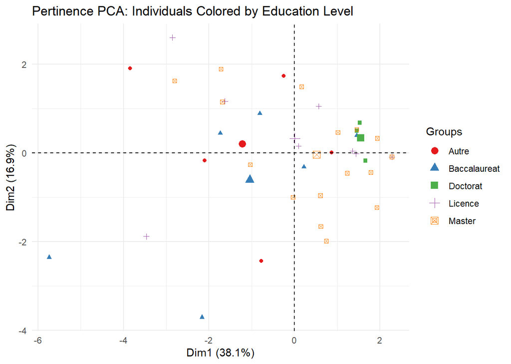

```r
# Individual biplot (colored by education level)
fviz_pca_ind(pertinence_pca, geom = "point", habillage = data$Quel.est.votre.niveau.d.etude) +
  scale_color_brewer(palette = "Set1") +
  ggtitle("Pertinence PCA: Individuals Colored by Education Level") + theme_minimal()
```

## 3.2 Bloc 2:Utilisation (Usage)(PCA)

This section looks at how respondents use their skills in their professional lives. PCA helps us analyze the degree to which these skills are utilized.

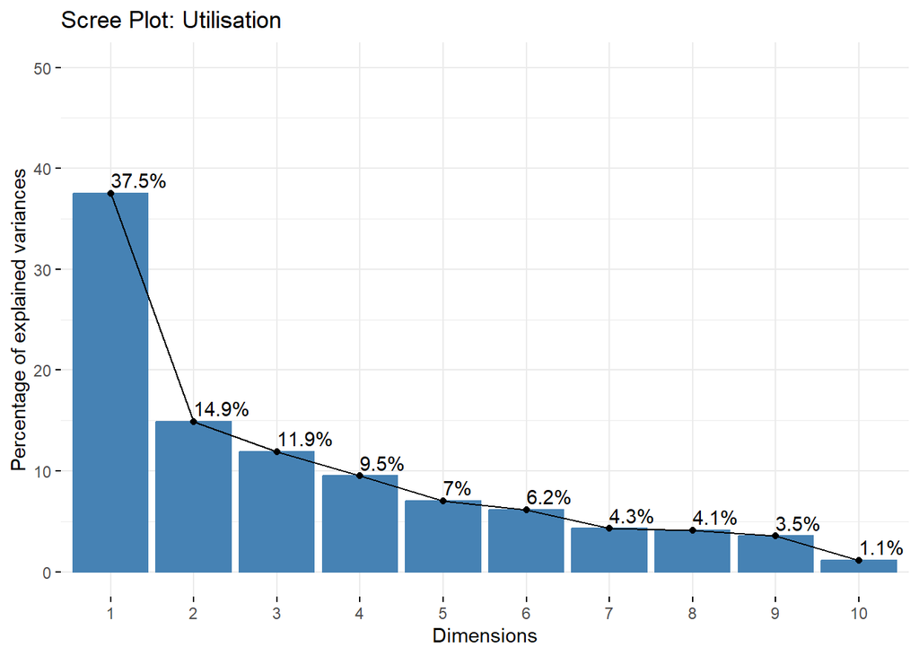

```r
# Select Utilisation-related columns
utilisation_columns <- grep("Utilisation", names(data), value = TRUE)
utilisation_data <- data %>%
  select(all_of(utilisation_columns)) %>%
  # Recode Likert responses into numeric values: pdtd -> 1, Neutre -> 2, tafd -> 3
  mutate(across(everything(),
                ~ recode(.,
                         "pdtd" = 1,
                         "Neutre" = 2,
                         "tafd" = 3,
                         .default = NA_real_)))

# Impute missing values with column means
utilisation_data[is.na(utilisation_data)] <- apply(utilisation_data, 2, function(x) mean(x, na.rm = TRUE))

# Standardize the data to have zero mean and unit variance
utilisation_scaled <- scale(utilisation_data)

# Identify and remove constant/zero-variance columns
col_variances <- apply(utilisation_scaled, 2, var)  # Calculate variances for each column
utilisation_scaled <- utilisation_scaled[, col_variances > 0]  # Remove columns with zero variance

# Perform PCA
utilisation_pca <- prcomp(utilisation_scaled, center = TRUE, scale. = TRUE)

# Scree plot to visualize the proportion of variance explained
fviz_screeplot(utilisation_pca, addlabels = TRUE, ylim = c(0, 50)) +
  ggtitle("Scree Plot: Utilisation")
```

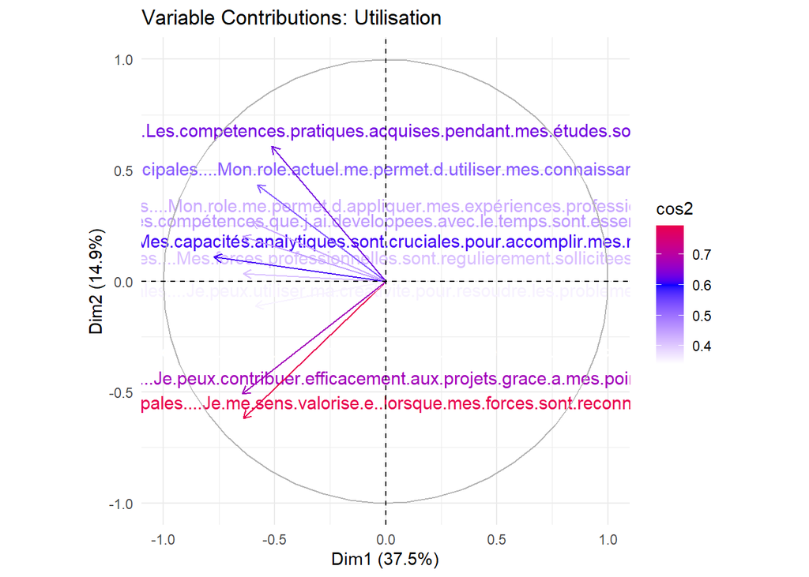

```r
# Variable biplot: Visualize how variables contribute to the principal components
fviz_pca_var(utilisation_pca, col.var = "cos2") +
  scale_color_gradient2(low = "white", mid = "blue", high = "red", midpoint = 0.6) +
  theme_minimal() +
  ggtitle("Variable Contributions: Utilisation")
```

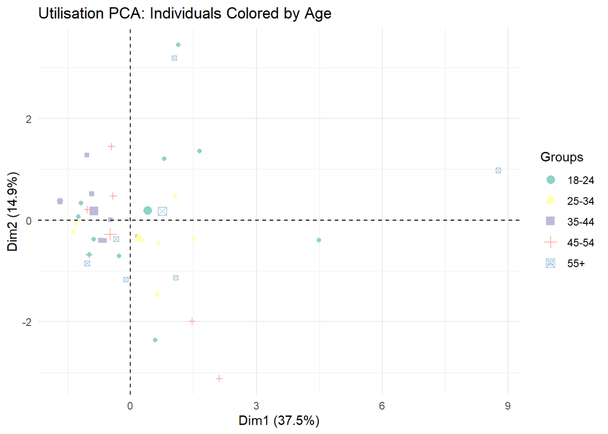

```r
# Individual biplot (colored by age)
fviz_pca_ind(utilisation_pca, geom = "point", habillage = data$age) +
  scale_color_brewer(palette = "Set3") +
  ggtitle("Utilisation PCA: Individuals Colored by Age") + theme_minimal()
```

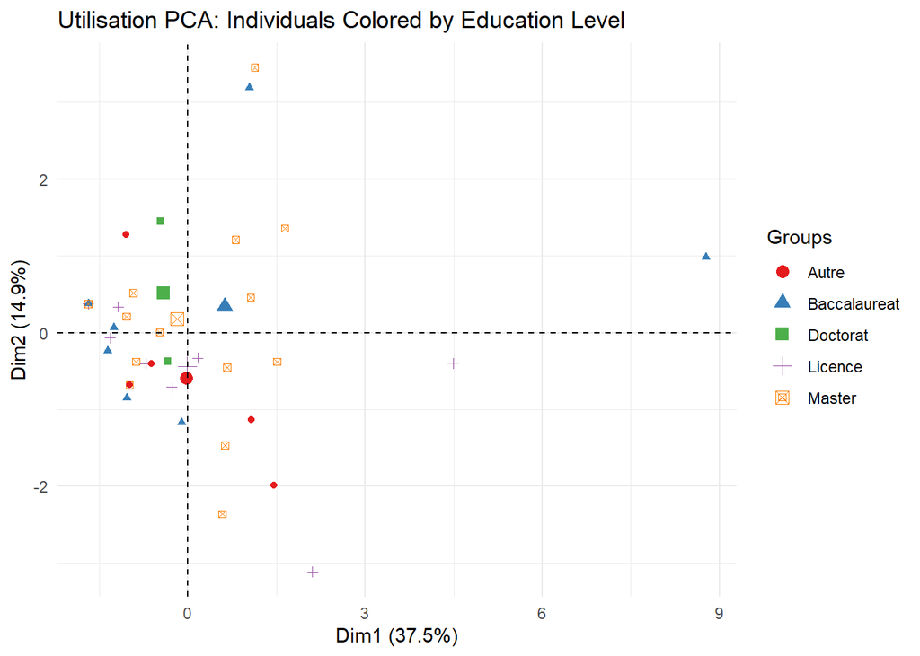

```r
# Individual biplot (colored by education level)
fviz_pca_ind(utilisation_pca, geom = "point", habillage = data$Quel.est.votre.niveau.d.etude) +
  scale_color_brewer(palette = "Set1") +
  ggtitle("Utilisation PCA: Individuals Colored by Education Level") + theme_minimal()
```

## 3.3 Bloc 3: Necessite(Necessity) (PCA)

In this block, we explore how much individuals feel the need to acquire new skills to adapt to their roles. PCA is applied again to extract valuable insights.

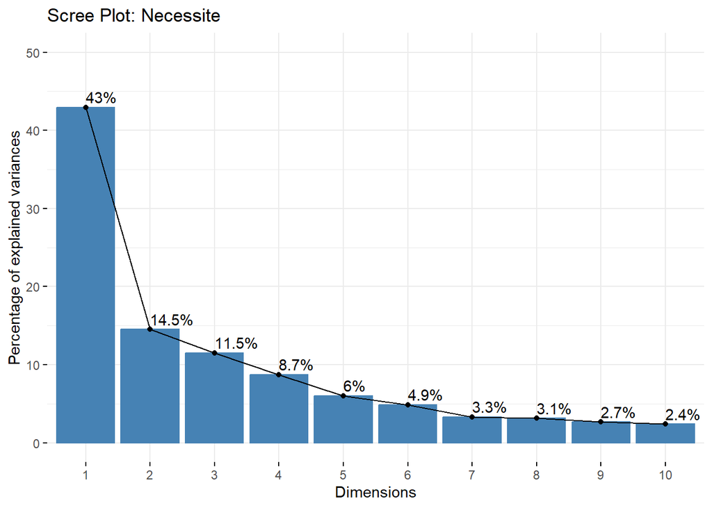

```r
# Select Necessite-related columns
necessite_columns <- grep("Necessite", names(data), value = TRUE)
necessite_data <- data %>%
  select(all_of(necessite_columns)) %>%
  # Recode Likert responses into numeric values: pdtd -> 1, Neutre -> 2, tafd -> 3
  mutate(across(everything(),
                ~ recode(.,
                         "pdtd" = 1,
                         "Neutre" = 2,
                         "tafd" = 3,
                         .default = NA_real_)))

# Impute missing values with column means
necessite_data[is.na(necessite_data)] <- apply(necessite_data, 2, function(x) mean(x, na.rm = TRUE))

# Standardize the data to have zero mean and unit variance
necessite_scaled <- scale(necessite_data)

# Identify and remove constant/zero-variance columns
col_variances <- apply(necessite_scaled, 2, var)  # Calculate variances for each column
necessite_scaled <- necessite_scaled[, col_variances > 0]  # Remove columns with zero variance

# Perform PCA
necessite_pca <- prcomp(necessite_scaled, center = TRUE, scale. = TRUE)

# Scree plot to visualize the proportion of variance explained
fviz_screeplot(necessite_pca, addlabels = TRUE, ylim = c(0, 50)) +
  ggtitle("Scree Plot: Necessite")
```

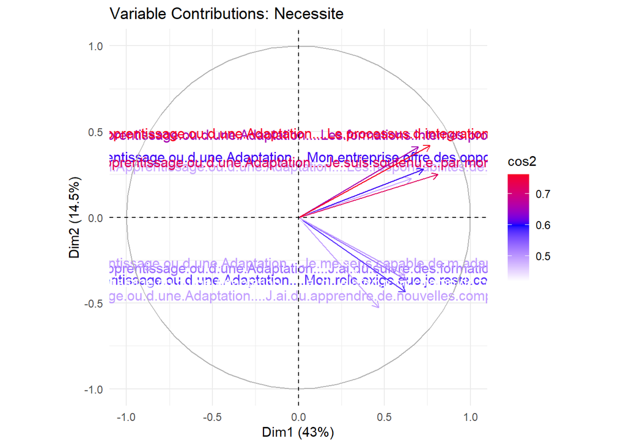

```r
# Variable biplot: Visualize how variables contribute to the principal components
fviz_pca_var(necessite_pca, col.var = "cos2") +
  scale_color_gradient2(low = "white", mid = "blue", high = "red", midpoint = 0.6) +
  theme_minimal() +
  ggtitle("Variable Contributions: Necessite")
```

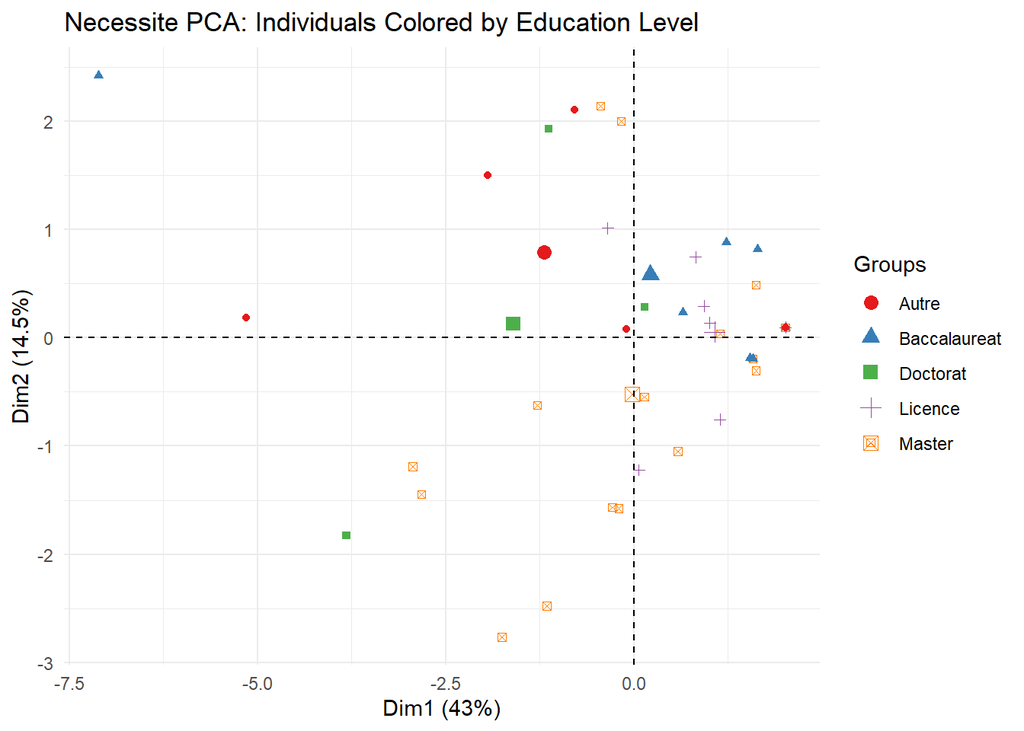

```r
# Individual biplot (colored by education level)
fviz_pca_ind(necessite_pca, geom = "point", habillage = data$Quel.est.votre.niveau.d.etude) +
  scale_color_brewer(palette = "Set1") +
  ggtitle("Necessite PCA: Individuals Colored by Education Level") + theme_minimal()
```

#Multiple Correspondence Analysis (MCA) I turn the attention to categorical variables to identify associations and trends. MCA helps me analyze these variables and provides insights into the connections between different categories.

# 4 Select Oui/Non columns for MCA(ACM in FR)

```r
objectifs_columns <- grep("Objectifs", names(data), value = TRUE)
objectifs_data <- data %>%
  select(all_of(objectifs_columns)) %>%
  # Convert to factors for MCA
  mutate(across(everything(), as.factor))
```

# 5 Remove columns with constant values or all NAs

```r
objectifs_data <- objectifs_data[, sapply(objectifs_data, function(col) length(unique(na.omit(col))) > 1)]
```

# 6 Perform MCA

```r
objectifs_mca <- MCA(objectifs_data, graph = FALSE)
```

# 7 Scree plot for MCA

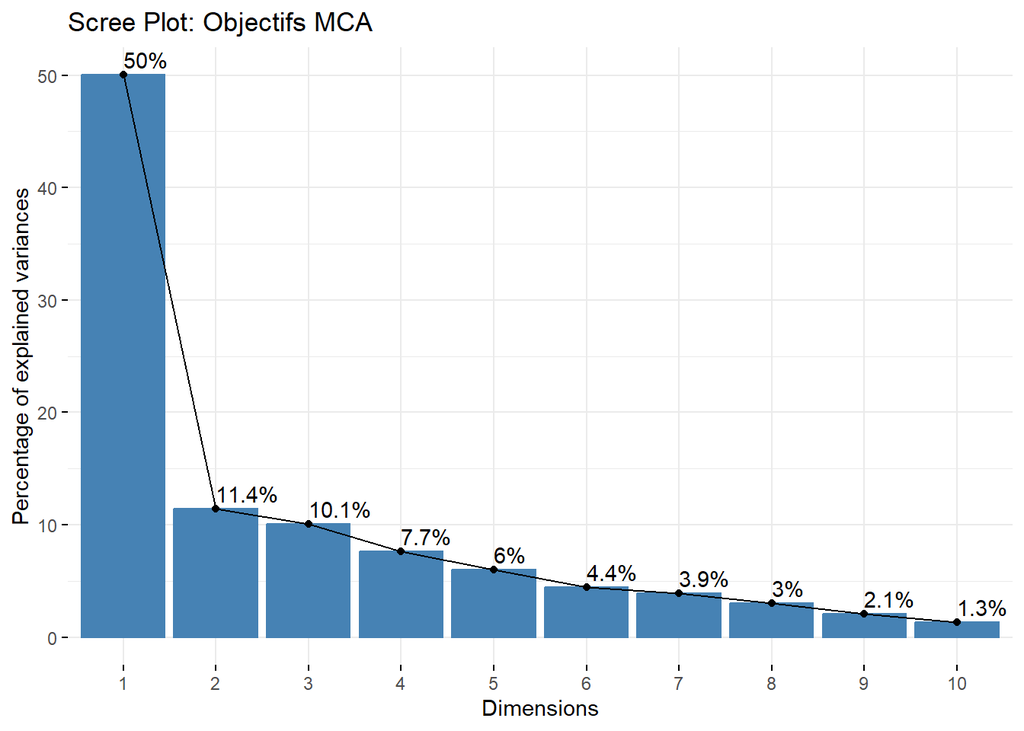

```r
fviz_screeplot(objectifs_mca, addlabels = TRUE, ylim = c(0, 50)) +
  ggtitle("Scree Plot: Objectifs MCA")
```

# 8 MCA biplot: Variables and individuals

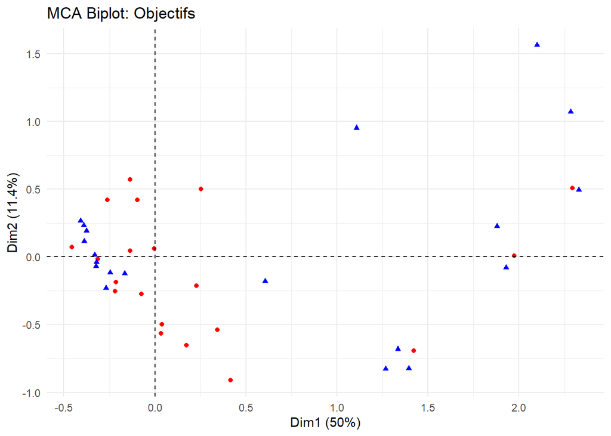

```r
fviz_mca_biplot(objectifs_mca, geom = "point", col.var = "blue", col.ind = "red") +
  ggtitle("MCA Biplot: Objectifs") + theme_minimal()
```

# 9 MCA biplot (colored by age)

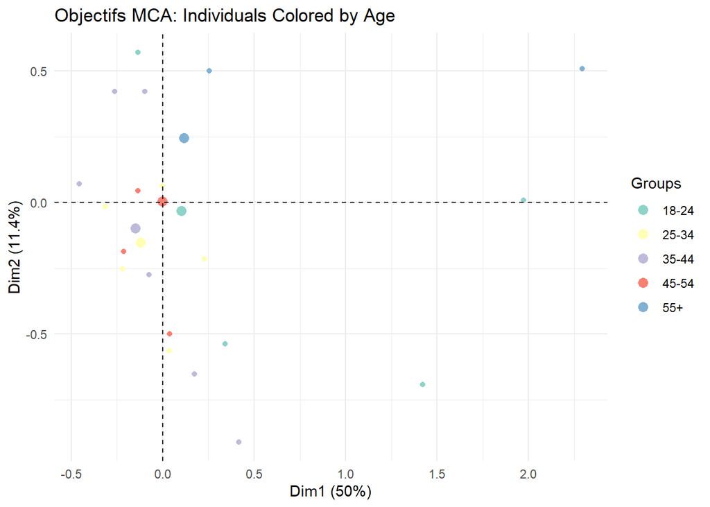

```r
fviz_mca_ind(objectifs_mca, geom = "point", habillage = data$age, palette = "Set3") +
  ggtitle("Objectifs MCA: Individuals Colored by Age") + theme_minimal()
```

# 10 MCA biplot (colored by education level)

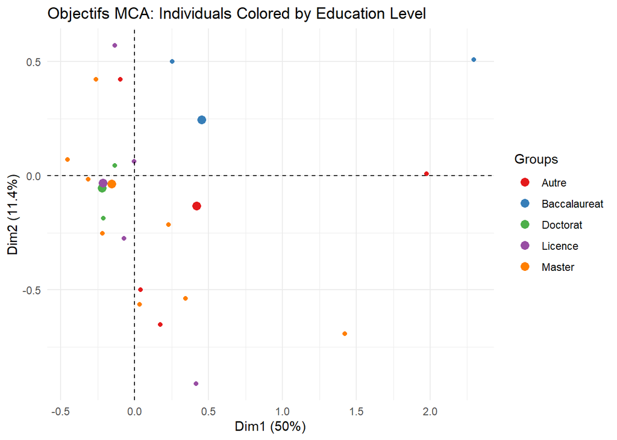

```r
# Ensure the education level column is a factor
data$Quel.est.votre.niveau.d.etude <- as.factor(data$Quel.est.votre.niveau.d.etude)

# Create the MCA biplot colored by education level
fviz_mca_ind(objectifs_mca, geom = "point", habillage = data$Quel.est.votre.niveau.d.etude, palette = "Set1") +
  ggtitle("Objectifs MCA: Individuals Colored by Education Level") + theme_minimal()
```

#Correspondence Analysis (AFC) in the Project

#Objective

Correspondence Analysis (AFC) was applied to investigate the relationship between respondents’ educational levels and their perceived need for learning or adaptation in their current roles. This analysis helps to visualize and interpret the associations between these categorical variables in a low-dimensional space.

#Steps and Implementation #Data Preparation

The analysis focused on two key survey variables: “Quel est votre niveau d’études?”: Represents the respondent’s educational level. “Nécessité d’un apprentissage ou d’une adaptation”: Indicates whether the respondent needed to acquire new skills to meet job requirements. These columns were extracted from the dataset and converted into factors to ensure compatibility with AFC requirements.

# 11 Contingency Table Creation

A contingency table was constructed to summarize the frequency of co-occurrence between the educational levels and the necessity of learning. This table is central to AFC as it quantifies the relationships between the categories of the two variables.

# 12 Profile Calculations

Row Profiles: Each row’s frequencies were normalized relative to the total for that row, allowing the analysis of distributions across columns for a given educational level. Column Profiles: Each column’s frequencies were normalized relative to the total for that column, providing insights into how respondents needing adaptation are distributed across educational levels.

# 13 Performing the AFC

AFC was conducted using the CA function from the FactoMineR package. This process decomposes the contingency table into principal components, enabling a geometric representation of the categorical data in a two-dimensional space.

#Visualization

A biplot was generated to visualize the results, where: Rows (educational levels) are represented in blue. Columns (necessity for learning) are represented in red. This plot highlights the proximity between categories, revealing patterns such as which educational levels are strongly associated with needing new skills.

#Summary of Results

The detailed summary includes: The contribution of each dimension to the variance. The quality of representation for each category. Inertia values, which indicate the importance of each dimension in explaining the relationship between variables.

#Insights Gained The AFC visualization helps uncover latent relationships between educational levels and the need for skill acquisition. Categories closer together in the biplot indicate stronger associations, while those further apart suggest weaker or no relationship.

#Data Preparation for AFC

I select appropriate categorical variables for correspondence analysis. to see the study level and the Necessity for Learning new skills

```r
# Select columns for Correspondence Analysis
categorical_columns <- grep("Quel.est.votre.niveau.d.etudes..|Necessite.d.un.Apprentissage.ou.d.une.Adaptation....J.ai.du.apprendre.de.nouvelles.compétences.pour.repondre.aux.exigences.de.mon.poste..", colnames(data), value = TRUE)

# Select the columns and convert to factors
afc_data <- data %>%
  select(all_of(categorical_columns)) %>%
  mutate(across(everything(), as.factor))  # Ensure variables are factors

# Create the contingency table for AFC
afc_table <- table(afc_data[[1]], afc_data[[2]])

# Display the contingency table
cat("Contingency Table:\n")
```

```
## Contingency Table:
```

```r
print(afc_table)
```

```
##
##                Neutre pdtd tafd
##   Autre             2    1    2
##   Baccalaureat      2    1    4
##   Doctorat          1    1    1
##   Licence           0    0    9
##   Master            1    0   16
```

```r
# Perform Correspondence Analysis (AFC)
afc_result <- CA(afc_table)
```

[figure not shown]

```r
# Row profiles (profile lines): Proportions for each row relative to the total of the respective row
row_profiles <- prop.table(afc_table, margin = 1)
cat("\nRow Profiles (Profile Lines):\n")
```

```
##
## Row Profiles (Profile Lines):
```

```r
print(row_profiles)
```

```
##
##                    Neutre       pdtd       tafd
##   Autre        0.40000000 0.20000000 0.40000000
##   Baccalaureat 0.28571429 0.14285714 0.57142857
##   Doctorat     0.33333333 0.33333333 0.33333333
##   Licence      0.00000000 0.00000000 1.00000000
##   Master       0.05882353 0.00000000 0.94117647
```

```r
# Column profiles (profile columns): Proportions for each column relative to the total of the respective column
col_profiles <- prop.table(afc_table, margin = 2)
cat("\nColumn Profiles (Profile Columns):\n")
```

```
##
## Column Profiles (Profile Columns):
```

```r
print(col_profiles)
```

```
##
##                   Neutre      pdtd      tafd
##   Autre        0.3333333 0.3333333 0.0625000
##   Baccalaureat 0.3333333 0.3333333 0.1250000
##   Doctorat     0.1666667 0.3333333 0.0312500
##   Licence      0.0000000 0.0000000 0.2812500
##   Master       0.1666667 0.0000000 0.5000000
```

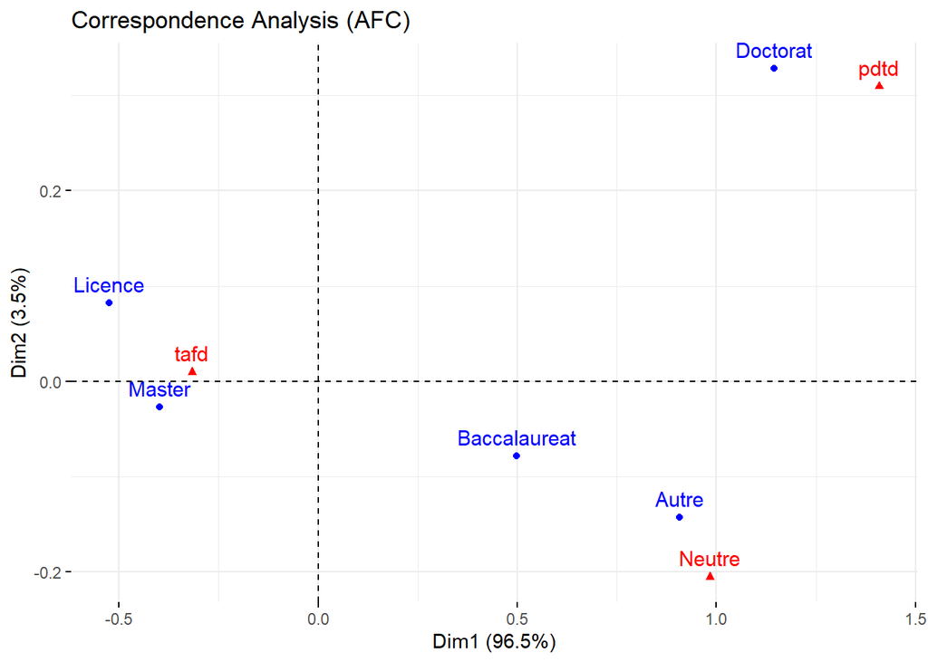

```r
# Plot the Correspondence Analysis biplot
fviz_ca_biplot(afc_result,
               col.row = "blue",    # Color rows (study level)
               col.col = "red",     # Color columns (Necessity for learning new skills)
               title = "Correspondence Analysis (AFC)")
```

```r
# Display detailed results of the Correspondence Analysis
cat("\nSummary of Correspondence Analysis:\n")
```

```
##
## Summary of Correspondence Analysis:
```

```r
summary(afc_result)
```

```
##
## Call:
## CA(X = afc_table)
##
## The chi square of independence between the two variables is equal to 15.49846 (p-value =  0.0501478 ).
##
## Eigenvalues
##                        Dim.1   Dim.2
## Variance               0.365   0.013
## % of var.             96.491   3.509
## Cumulative % of var.  96.491 100.000
##
## Rows
##                Iner*1000     Dim.1     ctr    cos2     Dim.2     ctr    cos2
## Autre        |   103.049 |   0.908  27.567   0.976 |  -0.143  18.830   0.024 |
## Baccalaureat |    43.554 |   0.499  11.651   0.976 |  -0.079   7.959   0.024 |
## Doctorat     |   103.913 |   1.145  26.321   0.924 |   0.329  59.608   0.076 |
## Licence      |    61.738 |  -0.524  16.516   0.976 |   0.083  11.282   0.024 |
## Master       |    65.758 |  -0.397  17.944   0.995 |  -0.027   2.321   0.005 |
##
## Columns
##                Iner*1000     Dim.1     ctr    cos2     Dim.2     ctr    cos2
## Neutre       |   147.589 |   0.983  38.769   0.958 |  -0.206  46.597   0.042 |
## pdtd         |   152.226 |   1.409  39.812   0.954 |   0.310  52.871   0.046 |
## tafd         |    78.196 |  -0.316  21.419   0.999 |   0.010   0.532   0.001 |
```

# 14 Conclusion

This study sheds light on how well academic pathways align with professional requirements and satisfaction. The analyses reveal patterns that can guide education policies and career planning, fostering a better match between skills and roles. By employing advanced statistical methods, this project contributes to the ongoing discourse on optimizing educational and professional outcomes.

In future work, further investigations could include larger datasets, longitudinal analyses, or more nuanced metrics of career satisfaction to deepen these findings.